# milestone210

## Project: Influence of news media on stock

```
        by Amara Midouhas and Rehan Mullan
```

```python
from google.colab import drive
drive.mount('/content/drive')
%cd /content/drive/My Drive/cmps3160/FinalDS
```

```
/content/drive/My Drive/cmps3160/FinalDS
```

**Goals of this Project**

We believe that the few Datasets that we do have,The New York times sentiment analysis, and the most influencial S&P 500 companies - Facebook, Amazon, Google, AMD, IBM and Tesla,are sufficient enough to help support our analysis. We are going to be using python libraries such as pandas, matplotlib, seaborn and jupyter labs as tools to help us complete this analysis.

Dataset 1: Sentiment Analysis of the New York Times

This Dataset contains values for over 30 years and multiple articles. The Data is filled with binary variables of multiple words usually associated with AI and technolgy such as - "Cyborg", "Singularity" and "Healthcare". These words and plenty others are placed into a negative or a positive column to judge the use of the word. Apart from these words we have columns with the article published date and time, paragraph and the section of the paper this was written under.

Dataset 2: S&P 500 historical data

This dataset contains multiple S&P 500 companies and their opening price, closing price, highest price and lowest price of the respective day. This dataset can help us see if even to a minor degree if the media can influence the stock market given that the stock market does seem to operate randomly. We do hope to see some relation if we're lucky.

Dataset 3: Exports and Imports

This dataset is the amount of money spent on imports and the value amount of exports in the United States. We will use it to see if an increase or decrease of either exports or imports affects the media's perception of new technological advancements and their behavior in the stock market.

Dataset 4: Amount invested in Research and Development

This dataset is the amount that the government put towards innovation of technological goods. We want to use this to see how it is affected by exports and imports. Then how less or more Research and Development affects innovation and people's perceptions towards AI.

# Collaboration Plan:

Our goal is to answer our question, " How has AI in the media impacted technology stocks?"

```python
# Read in the media's perception of AI dataset
import pandas as pd
perceptions_AI = pd.read_csv("robot-ai-all-public.csv")
#perceptions_AI = pd.DataFrame(perceptions_AI)
#perceptions_AI.head(5)
perceptions_AI
#split[0] is date
```

|  | Article ID | Article Date | Paragraph number | NYT section | Paragraph | Title | WorkTimeInSeconds | AI Mood | AI Relevance | Fiction | ... | Other (negative) | Cyborg (positive) | Decisions (positive) | Education (positive) | Entertain (positive) | Healthcare (positive) | Singularity (positive) | Transportation (positive) | Work (positive) | Other (positive) |
| --- | --- | --- | --- | --- | --- | --- | --- | --- | --- | --- | --- | --- | --- | --- | --- | --- | --- | --- | --- | --- | --- |
| 0 | 4fd1cbc98eb7c8105d701286 | 1996-10-06 00:00:00 UTC | 18 | New York and Region | Thus, next weekend will feature the robot who ... | LONG ISLAND JOURNAL | 1472 | 4 | 5 | 0 | ... | {} | 0 | 0 | 0 | 0 | 0 | 0 | 0 | 0 | {} |
| 1 | 4fd1cbc98eb7c8105d701286 | 1996-10-06 00:00:00 UTC | 18 | New York and Region | Thus, next weekend will feature the robot who ... | LONG ISLAND JOURNAL | 49 | 4 | 5 | 0 | ... | {} | 0 | 0 | 0 | 0 | 0 | 0 | 0 | 0 | {} |
| 2 | 4fd1cbc98eb7c8105d701286 | 1996-10-06 00:00:00 UTC | 18 | New York and Region | Thus, next weekend will feature the robot who ... | LONG ISLAND JOURNAL | 66 | 5 | 5 | 0 | ... | {} | 0 | 0 | 0 | 1 | 0 | 0 | 0 | 0 | {} |
| 3 | 54b0793b7988100e21965770 | 2006-07-31 00:00:00 UTC | 16 | Technology | That phrase was coined in the 1970۪s by Masahi... | Camera System Creates Sophisticated 3-D Effects | 3053 | 3 | 4 | 0 | ... | {} | 0 | 0 | 0 | 0 | 0 | 0 | 0 | 0 | {} |
| 4 | 54b0793b7988100e21965770 | 2006-07-31 00:00:00 UTC | 16 | Technology | That phrase was coined in the 1970۪s by Masahi... | Camera System Creates Sophisticated 3-D Effects | 25 | 3 | 4 | 0 | ... | {} | 0 | 0 | 0 | 0 | 0 | 0 | 0 | 0 | {} |
| ... | ... | ... | ... | ... | ... | ... | ... | ... | ... | ... | ... | ... | ... | ... | ... | ... | ... | ... | ... | ... | ... |
| 17068 | 566b44b87988100e80618c8f | 2015-12-12 00:00:00 UTC | 23 | Science | Also in 2014, the Microsoft A.I. researcher Er... | Artificial-Intelligence Research Center Is Fou... | 47 | 3 | 3 | 0 | ... | {} | 0 | 0 | 0 | 0 | 0 | 0 | 0 | 0 | {} |
| 17069 | 566b44b87988100e80618c8f | 2015-12-12 00:00:00 UTC | 23 | Science | Also in 2014, the Microsoft A.I. researcher Er... | Artificial-Intelligence Research Center Is Fou... | 378 | 3 | 2 | 0 | ... | {} | 0 | 0 | 0 | 0 | 0 | 0 | 0 | 0 | {} |
| 17070 | 566e112d79881065df1e156e | 2015-12-14 00:00:00 UTC | 8 | Business Day | The decision about the station rests with the ... | Howard University May Sell Rights to Its Publi... | 28 | 3 | 1 | 0 | ... | {} | 0 | 0 | 0 | 0 | 0 | 0 | 0 | 0 | {} |
| 17071 | 566e112d79881065df1e156e | 2015-12-14 00:00:00 UTC | 8 | Business Day | The decision about the station rests with the ... | Howard University May Sell Rights to Its Publi... | 331 | 3 | 1 | 0 | ... | {} | 0 | 0 | 0 | 0 | 0 | 0 | 0 | 0 | {} |
| 17072 | 566e112d79881065df1e156e | 2015-12-14 00:00:00 UTC | 8 | Business Day | The decision about the station rests with the ... | Howard University May Sell Rights to Its Publi... | 240 | 3 | 1 | 0 | ... | {} | 0 | 0 | 0 | 0 | 0 | 0 | 0 | 0 | {} |

17073 rows × 27 columns

```python
#delete unwanted columns and make date usable

s = perceptions_AI["Article Date"].str.split(" ",n = 3,expand=True)
perceptions_AI["Date"] = s[0]

del perceptions_AI["Article ID"]
del perceptions_AI["Article Date"]

del perceptions_AI["WorkTimeInSeconds"]
```

```python
#sort year in ascending order
perceptions_AI["Year"] = perceptions_AI["Date"].str.split("-",expand=True)[0].sort_index(ascending=True)
perceptions_AI.sort_values(by="Year",ascending=True,inplace=True)
perceptions_AI
```

|  | Paragraph number | NYT section | Paragraph | Title | AI Mood | AI Relevance | Fiction | Controling AI (negative) | Cyborg (negative) | Ethics (negative) | ... | Decisions (positive) | Education (positive) | Entertain (positive) | Healthcare (positive) | Singularity (positive) | Transportation (positive) | Work (positive) | Other (positive) | Date | Year |
| --- | --- | --- | --- | --- | --- | --- | --- | --- | --- | --- | --- | --- | --- | --- | --- | --- | --- | --- | --- | --- | --- |
| 3417 | 547db799798810275e384e54 | 2008-02-07T00:00:00Z | Science | NaN | 3 | 2 | 0 | 0 | 0 | 0 | ... | 0 | 0 | 0 | 0 | 0 | 0 | 0 | {} | 18 | 18 |
| 3418 | 547db799798810275e384e54 | 2008-02-07T00:00:00Z | Science | NaN | 3 | 1 | 0 | 0 | 0 | 0 | ... | 0 | 0 | 0 | 0 | 0 | 0 | 0 | {} | 18 | 18 |
| 3419 | 547db799798810275e384e54 | 2008-02-07T00:00:00Z | Science | NaN | 3 | 1 | 0 | 0 | 0 | 0 | ... | 0 | 0 | 0 | 0 | 0 | 0 | 0 | {} | 18 | 18 |
| 5100 | 8 | Science; Health | Videotapes made from the Alvin and flown ashor... | TITANIC'S EXPLORERS RETURN HOME TO CHEERS | 3 | 5 | 0 | 0 | 0 | 0 | ... | 0 | 0 | 0 | 0 | 0 | 0 | 0 | {} | 1986-07-29 | 1986 |
| 4193 | 0 | Business | DEARBORN, Mich. A TECHNICI... | Technology; A System Aids Use of Robots | 3 | 5 | 0 | 0 | 0 | 0 | ... | 0 | 0 | 0 | 0 | 0 | 0 | 0 | {} | 1986-04-17 | 1986 |
| ... | ... | ... | ... | ... | ... | ... | ... | ... | ... | ... | ... | ... | ... | ... | ... | ... | ... | ... | ... | ... | ... |
| 15427 | 6 | The Upshot | Technological singularity is this idea, almost... | Stuff We Liked: A Chance to Draw Trump | 3 | 5 | 0 | 0 | 0 | 0 | ... | 0 | 0 | 0 | 0 | 0 | 0 | 0 | {} | NaN | NaN |
| 15428 | 6 | The Upshot | Technological singularity is this idea, almost... | Stuff We Liked: A Chance to Draw Trump | 4 | 5 | 0 | 0 | 0 | 0 | ... | 0 | 0 | 0 | 0 | 1 | 0 | 1 | {} | NaN | NaN |
| 15429 | 11 | Technology | While DJI’s effort, which will go live in Dece... | Drone Maker DJI Adds Technology to Limit Where... | 3 | 4 | 0 | 0 | 0 | 0 | ... | 0 | 0 | 0 | 0 | 0 | 1 | 0 | {} | NaN | NaN |
| 15430 | 11 | Technology | While DJI’s effort, which will go live in Dece... | Drone Maker DJI Adds Technology to Limit Where... | 3 | 5 | 0 | 0 | 0 | 0 | ... | 0 | 0 | 0 | 0 | 0 | 0 | 0 | {} | NaN | NaN |
| 15431 | 11 | Technology | While DJI’s effort, which will go live in Dece... | Drone Maker DJI Adds Technology to Limit Where... | 3 | 4 | 0 | 0 | 0 | 0 | ... | 0 | 0 | 0 | 0 | 0 | 0 | 0 | {} | NaN | NaN |

17073 rows × 26 columns

We made sure that we knew each of the data types in our data by calling upon dtypes.

```python
#print all the data types we see that date and year are not the right data type
perceptions_AI.dtypes
```

```
Paragraph number             object
NYT section                  object
Paragraph                    object
Title                        object
AI Mood                       int64
AI Relevance                  int64
Fiction                       int64
Controling AI (negative)      int64
Cyborg (negative)             int64
Ethics (negative)             int64
Military (negative)           int64
Progress (negative)           int64
Singularity (negative)        int64
Work (negative)               int64
Other (negative)             object
Cyborg (positive)             int64
Decisions (positive)          int64
Education (positive)          int64
Entertain (positive)          int64
Healthcare (positive)         int64
Singularity (positive)        int64
Transportation (positive)     int64
Work (positive)               int64
Other (positive)             object
Date                         object
Year                         object
dtype: object
```

Here we realized that a lot of our data contained NAN values. to get rid of those we had to drop all of those values. this reduced our data signinficantly. but we still had plenty of data to work with.

```python
perceptions_AI.value_counts("Date")
##multiple values in same bin messing up our graphs: want to take the average of the sentiment
#perceptions_AI[perceptions_AI["Date"] == "2015-02-23"]
perceptions_AI = perceptions_AI.dropna().reset_index(drop=True)
perceptions_AI.value_counts("NYT section")
perceptions_AI[perceptions_AI["NYT section"] == "Movies; Arts; Books"]
```

|  | Paragraph number | NYT section | Paragraph | Title | AI Mood | AI Relevance | Fiction | Controling AI (negative) | Cyborg (negative) | Ethics (negative) | ... | Decisions (positive) | Education (positive) | Entertain (positive) | Healthcare (positive) | Singularity (positive) | Transportation (positive) | Work (positive) | Other (positive) | Date | Year |
| --- | --- | --- | --- | --- | --- | --- | --- | --- | --- | --- | --- | --- | --- | --- | --- | --- | --- | --- | --- | --- | --- |
| 1696 | 8 | Movies; Arts; Books | Although the word utopia was coined by Sir Tho... | THIS WEEK | 3 | 2 | 0 | 0 | 0 | 0 | ... | 0 | 0 | 0 | 0 | 0 | 0 | 0 | {} | 2000-10-09 | 2000 |
| 1697 | 8 | Movies; Arts; Books | Although the word utopia was coined by Sir Tho... | THIS WEEK | 3 | 2 | 0 | 0 | 0 | 0 | ... | 0 | 0 | 0 | 0 | 0 | 0 | 0 | {} | 2000-10-09 | 2000 |
| 1701 | 8 | Movies; Arts; Books | Although the word utopia was coined by Sir Tho... | THIS WEEK | 3 | 3 | 0 | 0 | 0 | 0 | ... | 0 | 0 | 0 | 0 | 0 | 0 | 0 | {} | 2000-10-09 | 2000 |
| 2779 | 15 | Movies; Arts; Books | The robot could also become an answer to human... | For Asimov, Robots Were Friends. Not So for Wi... | 2 | 4 | 1 | 1 | 0 | 0 | ... | 0 | 0 | 0 | 0 | 0 | 0 | 0 | {} | 2004-07-15 | 2004 |
| 2780 | 15 | Movies; Arts; Books | The robot could also become an answer to human... | For Asimov, Robots Were Friends. Not So for Wi... | 3 | 5 | 1 | 0 | 0 | 0 | ... | 0 | 0 | 0 | 0 | 0 | 0 | 0 | {} | 2004-07-15 | 2004 |
| 2781 | 15 | Movies; Arts; Books | The robot could also become an answer to human... | For Asimov, Robots Were Friends. Not So for Wi... | 5 | 5 | 1 | 0 | 0 | 0 | ... | 0 | 0 | 0 | 0 | 0 | 0 | 0 | {} | 2004-07-15 | 2004 |
| 3034 | 11 | Movies; Arts; Books | But these laws weren't the source of Asimov's ... | For Asimov, Robots Were Friends. Not So for Wi... | 3 | 3 | 0 | 0 | 0 | 0 | ... | 0 | 0 | 0 | 0 | 0 | 0 | 0 | {} | 2004-07-15 | 2004 |
| 3035 | 11 | Movies; Arts; Books | But these laws weren't the source of Asimov's ... | For Asimov, Robots Were Friends. Not So for Wi... | 4 | 5 | 0 | 0 | 0 | 0 | ... | 0 | 0 | 0 | 0 | 0 | 0 | 0 | {} | 2004-07-15 | 2004 |
| 3036 | 11 | Movies; Arts; Books | But these laws weren't the source of Asimov's ... | For Asimov, Robots Were Friends. Not So for Wi... | 3 | 4 | 0 | 0 | 0 | 0 | ... | 0 | 0 | 0 | 0 | 0 | 0 | 0 | {} | 2004-07-15 | 2004 |

9 rows × 26 columns

cleaning of AI DataSet

- To make the dataset tidy, we first split the Article Date so that we could just get the date and made it into a new column of its own. we then deleted some other columns that we thought would not contribute to any analysis.

```python
#here we finish cleaning up the rows

toDrop = ['New York and Region', 'Home and Garden','Arts', 'Sports', 'Education; U.S.', 'Travel', 'Education; New York and Region' ,
'Movies; Arts', 'World; Washington', 'Arts; Books', 'Arts; Books; Opinion', 'World', 'Health; New York and Region', 'Unknown', 'Style',
'Home and Garden; Style','Health; U.S.', 'Arts; Theater', 'Obituaries', 'Style; Washington', 'Movies; Week in Review', 'Movies', 'Front Page',
'Movies; Arts; Books', 'Real Estate', 'Education', 'Health; Magazine', 'Movies; Business','U.S.; Washington','Magazine; Books', 'Education; Sports',
'World; Health', 'Education; Business', 'Corrections; New York and Region', 'Home and Garden; Arts; Style; Magazine', 'Movies; Style','Movies; Magazine',
'Health','Arts; Obituaries', 'Business Day', 'Magazine; Washington', 'N.Y./Region', 'Fashion & Style', 'Week In Review','Style; Magazine', 'Theater', 'Sunday Magazine',
'Corrections', 'Home & Garden', 'T:Style', 'Crosswords/Games', 'Multimedia', 'Open', 'Paid Death Notices', 'Crosswords & Games', 'Health; Science', 'Arts; Style; Magazine',
'Great Homes & Destinations', 'The Upshot','T Magazine', 'FALSE', 'Giving', 'NYT Now', 'Universal']

#perceptions_AI.index(perceptions_AI[perceptions_AI["Title"] == "Business"])
for i in toDrop:
    indexestoDrop = perceptions_AI[perceptions_AI["NYT section"] == i].index
    perceptions_AI.drop(index=indexestoDrop, axis = 0, inplace=True)
```

```python
#We finally change the data types of year and Date
perceptions_AI['Date'] = pd.to_datetime(perceptions_AI["Date"],format="%Y-%m-%d")
perceptions_AI["Year"] = pd.to_datetime(perceptions_AI["Year"],format="%Y")
perceptions_AI.dtypes
```

```
Paragraph number                     object
NYT section                          object
Paragraph                            object
Title                                object
AI Mood                               int64
AI Relevance                          int64
Fiction                               int64
Controling AI (negative)              int64
Cyborg (negative)                     int64
Ethics (negative)                     int64
Military (negative)                   int64
Progress (negative)                   int64
Singularity (negative)                int64
Work (negative)                       int64
Other (negative)                     object
Cyborg (positive)                     int64
Decisions (positive)                  int64
Education (positive)                  int64
Entertain (positive)                  int64
Healthcare (positive)                 int64
Singularity (positive)                int64
Transportation (positive)             int64
Work (positive)                       int64
Other (positive)                     object
Date                         datetime64[ns]
Year                         datetime64[ns]
dtype: object
```

```python
import numpy as np
import seaborn as sns
sns.set_style("dark")
#Cyborg (negative)             int64
other_vars = ["Paragraph number", "NYT section", "Paragraph","Title","AI Mood","AI Relevance","Fiction","Date"]
positives = ["Cyborg (positive)", "Decisions (positive)", "Education (positive)", "Entertain (positive)","Healthcare (positive)", "Singularity (positive)","Transportation (positive)", "Work (positive)"]
negatives = ["Work (negative)", "Controling AI (negative)", "Cyborg (negative)", "Ethics (negative)", "Military (negative)", "Progress (negative)", "Singularity (negative)"]

horizontalIndex = positives + negatives

#other_vars = ["Paragraph number", "NYT section", "Paragraph","Title","AI Mood","AI Relevance","Fiction","Date", "positives"]
new_perceptions = pd.melt(perceptions_AI, id_vars = other_vars + negatives, value_vars=positives, var_name=["positives"], value_name= "positive points",ignore_index=True)
other_vars = other_vars + ["positives", "positive points"]

new1_perception = pd.melt(new_perceptions, id_vars= other_vars, value_vars=negatives,var_name=["negatives"], value_name = "negative points", ignore_index=True)
new1_perception

#for_table = new_perceptions[["Title", "Sentiment"]]
#for_table

table_positives = pd.pivot_table(new1_perception, values=["positive points"], index=["NYT section"], columns=["positives"],aggfunc=np.sum)
table_positives = table_positives.loc[~(table_positives==0).all(axis=1)]
table_positives
```

| positives NYT section | positive points Cyborg (positive) | positive points Decisions (positive) | positive points Education (positive) | positive points Entertain (positive) | positive points Healthcare (positive) | positive points Singularity (positive) | positive points Transportation (positive) | positive points Work (positive) |
| --- | --- | --- | --- | --- | --- | --- | --- | --- |
| Automobiles | 0 | 0 | 0 | 0 | 0 | 0 | 35 | 0 |
| Autos | 7 | 0 | 0 | 28 | 0 | 0 | 28 | 0 |
| Blogs | 7 | 7 | 7 | 0 | 14 | 0 | 0 | 0 |
| Books | 7 | 7 | 7 | 42 | 28 | 0 | 21 | 7 |
| Business | 7 | 28 | 14 | 84 | 49 | 0 | 112 | 322 |
| Business; Books | 7 | 0 | 0 | 0 | 0 | 0 | 0 | 0 |
| Front Page; Health; U.S. | 0 | 0 | 0 | 0 | 0 | 0 | 0 | 7 |
| Front Page; New York and Region | 0 | 0 | 0 | 0 | 0 | 0 | 0 | 7 |
| Front Page; U.S. | 0 | 0 | 0 | 0 | 0 | 7 | 28 | 7 |
| Health; Business | 7 | 0 | 0 | 0 | 14 | 0 | 0 | 21 |
| Job Market | 0 | 0 | 0 | 0 | 0 | 0 | 0 | 7 |
| Magazine | 35 | 42 | 21 | 98 | 49 | 14 | 14 | 98 |
| N.Y. / Region | 7 | 28 | 21 | 49 | 0 | 7 | 14 | 49 |
| Opinion | 70 | 175 | 63 | 42 | 112 | 42 | 161 | 245 |
| Science | 112 | 91 | 161 | 105 | 112 | 42 | 427 | 420 |
| Science; Books; Opinion | 7 | 0 | 0 | 0 | 0 | 0 | 0 | 0 |
| Science; Front Page; Health; Corrections; Editors' Notes | 0 | 0 | 0 | 0 | 21 | 0 | 0 | 0 |
| Science; Health | 7 | 28 | 91 | 35 | 21 | 21 | 322 | 140 |
| Science; Opinion | 0 | 0 | 0 | 0 | 7 | 0 | 0 | 0 |
| Science; Technology | 0 | 0 | 7 | 0 | 0 | 0 | 0 | 0 |
| Science; Technology; Business | 7 | 0 | 0 | 0 | 0 | 0 | 35 | 7 |
| Science; Technology; Front Page; Business | 14 | 0 | 0 | 0 | 0 | 0 | 14 | 14 |
| Sunday Review | 7 | 21 | 0 | 7 | 7 | 0 | 14 | 0 |
| Technology | 91 | 427 | 189 | 623 | 441 | 91 | 343 | 1106 |
| Technology; Arts | 7 | 7 | 7 | 14 | 0 | 0 | 0 | 7 |
| Technology; Books | 0 | 0 | 0 | 0 | 0 | 0 | 7 | 0 |
| Technology; Business | 21 | 21 | 21 | 14 | 14 | 0 | 42 | 140 |
| Technology; Business; Books | 0 | 0 | 7 | 0 | 0 | 0 | 0 | 0 |
| Technology; Education | 0 | 0 | 7 | 21 | 0 | 0 | 0 | 0 |
| Technology; Education; New York and Region | 0 | 0 | 7 | 0 | 0 | 0 | 0 | 0 |
| Technology; Education; U.S. | 0 | 0 | 0 | 14 | 0 | 0 | 0 | 0 |
| Technology; Front Page; Business | 7 | 0 | 0 | 0 | 0 | 7 | 0 | 0 |
| Technology; Health | 0 | 0 | 0 | 0 | 21 | 0 | 0 | 7 |
| Technology; Health; Magazine | 0 | 7 | 0 | 0 | 0 | 0 | 0 | 0 |
| Technology; Health; New York and Region | 0 | 0 | 0 | 0 | 35 | 0 | 0 | 0 |
| Technology; Home and Garden; Style | 0 | 0 | 0 | 0 | 0 | 0 | 0 | 7 |
| Technology; Magazine | 14 | 0 | 0 | 7 | 0 | 0 | 0 | 7 |
| Technology; New York and Region | 0 | 0 | 7 | 0 | 0 | 0 | 0 | 0 |
| Technology; Opinion | 7 | 7 | 14 | 14 | 0 | 7 | 0 | 14 |
| Technology; Science; Arts; Theater | 0 | 0 | 0 | 14 | 0 | 0 | 0 | 0 |
| Technology; Science; Health | 7 | 35 | 0 | 7 | 35 | 7 | 35 | 70 |
| Technology; Science; Home and Garden; Style | 0 | 0 | 0 | 0 | 0 | 0 | 7 | 0 |
| Technology; Science; Magazine | 14 | 28 | 21 | 42 | 0 | 0 | 0 | 28 |
| Technology; Science; Travel | 0 | 0 | 7 | 14 | 14 | 0 | 7 | 0 |
| Technology; Science; U.S. | 0 | 0 | 0 | 0 | 0 | 0 | 7 | 0 |
| Technology; Science; World; Education | 0 | 7 | 7 | 0 | 0 | 0 | 0 | 7 |
| Technology; Style | 0 | 0 | 0 | 7 | 0 | 0 | 0 | 0 |
| Technology; U.S. | 14 | 7 | 7 | 0 | 0 | 0 | 0 | 7 |
| Technology; Week in Review | 0 | 21 | 0 | 0 | 0 | 0 | 0 | 7 |
| U.S. | 42 | 119 | 168 | 77 | 70 | 49 | 441 | 385 |
| Week in Review | 7 | 0 | 7 | 14 | 0 | 28 | 35 | 7 |
| World; Front Page | 0 | 7 | 0 | 0 | 0 | 0 | 0 | 0 |
| Your Money | 0 | 7 | 0 | 0 | 0 | 0 | 0 | 7 |

person would need to zoom into this one to see the data but heres the plot

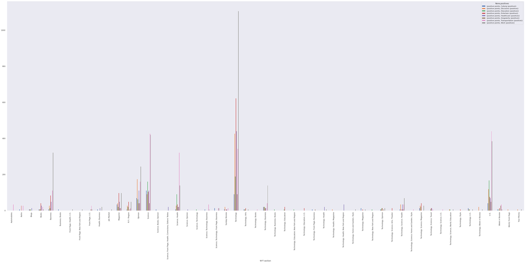

```python
#plotting the first pivot table for positive sentiment
table_positives.plot.bar(figsize=(60,25))
```

```python
#Here we do the same for negative sentiment-creating a pivot table with negative sentiment and sum the boolean values
table_negatives = pd.pivot_table(new1_perception, index=["NYT section"], values=["negative points"], columns="negatives",aggfunc=np.sum)
table_negatives = table_negatives.loc[~(table_negatives==0).all(axis=1)]
table_negatives
```

| negatives NYT section | negative points Controling AI (negative) | negative points Cyborg (negative) | negative points Ethics (negative) | negative points Military (negative) | negative points Progress (negative) | negative points Singularity (negative) | negative points Work (negative) |
| --- | --- | --- | --- | --- | --- | --- | --- |
| Books | 0 | 16 | 0 | 0 | 8 | 0 | 0 |
| Business | 16 | 8 | 0 | 48 | 96 | 0 | 56 |
| Front Page; Health; U.S. | 0 | 0 | 0 | 0 | 8 | 0 | 0 |
| Front Page; New York and Region | 8 | 0 | 0 | 0 | 0 | 8 | 0 |
| Health; Business | 0 | 0 | 0 | 0 | 0 | 0 | 8 |
| Magazine | 56 | 8 | 40 | 48 | 56 | 24 | 8 |
| N.Y. / Region | 0 | 0 | 0 | 0 | 16 | 0 | 8 |
| Opinion | 192 | 40 | 128 | 120 | 128 | 96 | 256 |
| Science | 104 | 8 | 40 | 72 | 64 | 24 | 56 |
| Science; Health | 0 | 0 | 0 | 8 | 24 | 0 | 0 |
| Science; Health; Books | 24 | 0 | 0 | 0 | 0 | 0 | 0 |
| Science; Technology; Business | 0 | 0 | 0 | 0 | 16 | 0 | 0 |
| Science; Technology; Front Page; Business | 0 | 0 | 0 | 120 | 0 | 8 | 0 |
| Sunday Review | 8 | 8 | 0 | 0 | 16 | 0 | 0 |
| Technology | 152 | 32 | 56 | 136 | 160 | 72 | 144 |
| Technology; Arts; Books | 0 | 0 | 0 | 0 | 8 | 0 | 0 |
| Technology; Arts; Washington | 0 | 0 | 0 | 8 | 0 | 0 | 0 |
| Technology; Business | 0 | 0 | 0 | 8 | 8 | 0 | 0 |
| Technology; Front Page; U.S. | 0 | 0 | 0 | 0 | 0 | 8 | 0 |
| Technology; Health; New York and Region | 0 | 0 | 0 | 0 | 0 | 0 | 8 |
| Technology; Movies | 8 | 0 | 0 | 0 | 0 | 0 | 0 |
| Technology; Opinion | 0 | 8 | 0 | 0 | 8 | 0 | 0 |
| Technology; Science; Arts; Theater | 0 | 0 | 0 | 0 | 0 | 8 | 0 |
| Technology; Science; Health | 0 | 0 | 8 | 24 | 16 | 0 | 0 |
| Technology; Science; Magazine | 0 | 0 | 8 | 0 | 0 | 0 | 0 |
| Technology; Week in Review | 32 | 0 | 0 | 32 | 0 | 24 | 0 |
| U.S. | 40 | 8 | 0 | 16 | 24 | 0 | 0 |
| Week in Review | 16 | 0 | 8 | 16 | 0 | 0 | 0 |
| Your Money | 0 | 0 | 0 | 0 | 0 | 0 | 8 |

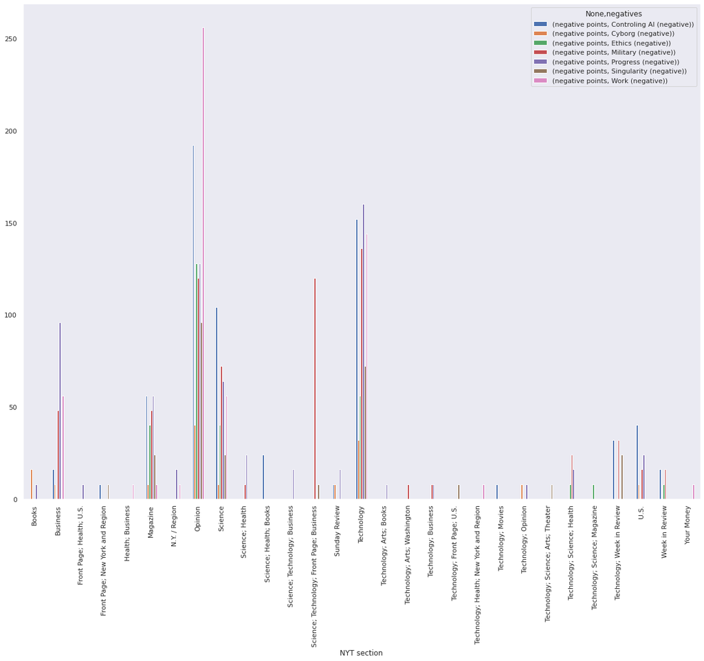

```python
#plotting the negative values
table_negatives.plot.bar(figsize=(20,15))
```

Showing the bias

```python
#We did this to weigh the total sentiment
posSum = new1_perception["positive points"].sum() #14595
negSum = new1_perception["negative points"].sum() #4408 initial numbers before focusing
dict ={"positives":posSum, "negatives":negSum}
dict
```

```
{'positives': 10598, 'negatives': 3216}
```

we see that the data set is leaning more towards the positive sentiment

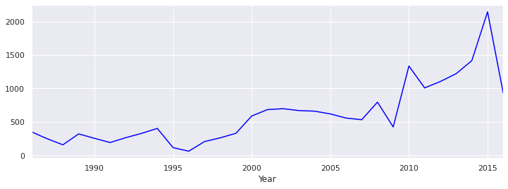

```python
#this is for our plot of average mood over time
import seaborn as sns
import matplotlib.pyplot as plt
sns.set_style("dark")


#perceptions_AI.groupby("Year")["AI Mood"].sum().plot(figsize=(12,4),color="black").set(xlabel="Year", ylabel="AI Mood")
#perceptions_AI
sns.set(rc={'figure.figsize':(12,9)})
MoodSum = perceptions_AI.groupby("Year")["AI Mood"].sum().plot(figsize=(12,4),color="blue")


#new1_perception
```

run regression on this line and predict points for the next 4 years, find another dataset. data set to make this relation more concrete/ more exploratory. maybe figure how plot new technologies on this graph. ecnomic growth,

# TABLE PART 2

For our second table we selected one of the data sets from the S&P 500 data. Here we selected Apple just to demonstrate that this could be useful in helping analyze our question. Since this data was clean and could be used as is we did not have much to clean. We started off by calling descibe to see what part of our data could be useful.

```python
%cd Technology\ Companies
apple = pd.read_csv("AAPL.csv")
apple.describe()
nvidia = pd.read_csv("NVDA.csv")
AMD = pd.read_csv("AMD.csv")

#apple.head()
```

```
/content/drive/My Drive/cmps3160/FinalDS/Technology Companies
```

```python
!ls
```

```
 AAPL.csv   COUP.csv			 GRMN.csv   OKTA.csv   TER.csv
 ACN.csv    CRM.csv			 HPQ.csv    ORCL.csv   TRMB.csv
 ADBE.csv   CRWD.csv			 HUBS.csv   PANW.csv   TSLA.csv
 ADI.csv    CSCO.csv			 IBM.csv    PAYC.csv   TSM.csv
 ADSK.csv   CTSH.csv			 INFY.csv   PLTR.csv   TXN.csv
 AKAM.csv   CTXS.csv			 INTC.csv   QCOM.csv   TYL.csv
 AMAT.csv   DDOG.csv			 INTU.csv   QRVO.csv   UBER.csv
 AMD.csv    DELL.csv			 KEYS.csv   RNG.csv    U.csv
 ANET.csv   DOCU.csv			 KLAC.csv   SAP.csv    UI.csv
 ANSS.csv   EPAM.csv			 LRCX.csv   SHOP.csv   UMC.csv
 APH.csv    ERIC.csv			 MCHP.csv   SNE.csv    VMW.csv
 ASML.csv   FIS.csv			 MRVL.csv   SNPS.csv   VRSN.csv
 AVGO.csv   FISV.csv			 MSFT.csv   SPLK.csv   WDAY.csv
 AVLR.csv   FLT.csv			 MSI.csv    SQ.csv     WIT.csv
 BR.csv     FTNT.csv			 MU.csv     SSNC.csv   WORK.csv
 CAJ.csv    FTV.csv			 MXIM.csv   STM.csv    XLNX.csv
 CCC.csv    FTV-PA.csv			 NET.csv    STX.csv    ZBRA.csv
 CDNS.csv   GIB.csv			 NOW.csv    SWKS.csv   ZEN.csv
 CDW.csv    GLW.csv			 NVDA.csv   TEAM.csv   ZI.csv
 CHKP.csv  'GOOGL Historical Data.csv'	 NXPI.csv   TEL.csv    ZS.csv
```

we came to the conclusion that the mean of highs and lows would be the perefect thing to plot and look at. so we made another column which was just that. after plotting this we could see the general trend of the Apple stock. using seaborn here we were able to plot it and seee that the trajectory was rising exponentially.

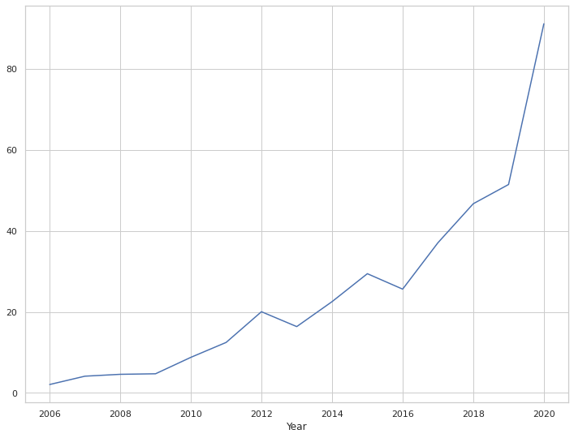

```python
sns.set_style("whitegrid")

apple["Year"] = apple["Date"].str.split("-",expand=True)[0]
#high = apple.groupby("Year")["High"].sum()
#low =
apple["mean"] = (apple["High"] + apple["Low"]) //2
apple.groupby("Year")["mean"].mean().plot()
#.lineplot(data=apple,x = "Year",y = "mean",color="blue")
#apple.head()
```

# Table 3

```python
%cd ..
```

```
/content/drive/My Drive/cmps3160/FinalDS
```

The third table is the United States Trade Flow

```python
import pandas as pd
# Read in the export and import of goods
export_imports = pd.read_csv("export_Import.csv")

#export.loc[export['End-use category']=='Intermediate']
export_imports.drop(labels=["COU","Partners","FLW","PAR","CAT","IND","VAL","TIME","Flag Codes","Flags","Value"], inplace=True, axis=1)
export_imports.value_counts("End-use category")
```

```
End-use category
Total trade in goods     27029
Intermediate goods       26678
Capital goods            25907
Household consumption    24048
Mixed end-use            14408
Miscellaneous             9744
Personal computers        7869
Personal phones           7131
Packed medicines          2288
Passenger cars            2154
Precious goods            1990
dtype: int64
```

```python
#Checking all the different industries
export_imports["Industry"].value_counts()
```

```
High Technology Industries                                      22300
Information and Communication Technology (ICT) Manufactures     18057
Medium-High Technology Industries                               17293
Low-Technology Industries                                       16597
Radio, Television and Communication Equipment                   15019
Office, Accounting and Computing Machinery                      14295
Machinery and Equipment, not elsewhere classified               12771
Medium-Low Technology Industries                                12290
Medical, Precision and Optical Instruments                      10463
Electrical Machinery and Apparatus, not elsewhere classified    10161
Name: Industry, dtype: int64
```

We seperated the exports and imports into two dataframes to understand their relationship with each other and plot them against each other.

```python
#Make new dataframe with just exports
exports = pd.DataFrame(export_imports[export_imports["Trade Flow"] == "Exports"])
exports.reset_index(drop=True,inplace=True)

exports.rename(mapper={"Value.1": "Values in thousand (exports)"},axis=1,inplace=True)

#exports.drop(labels=["Value"],axis=1)
#Make new dataframe with imports
imports = pd.DataFrame(export_imports[export_imports["Trade Flow"] == "Imports"])
imports.reset_index(drop=True,inplace=True)
imports.rename(mapper={"Value.1": "Values in thousand (imports)"},axis=1,inplace=True)
#imports.drop(labels=["Value"],axis=1)
imports
```

|  | Country | Trade Flow | End-use category | Industry | Time | Values in thousand (imports) |
| --- | --- | --- | --- | --- | --- | --- |
| 0 | United States | Imports | Total trade in goods | Machinery and Equipment, not elsewhere classified | 1990 | 37704305 |
| 1 | United States | Imports | Total trade in goods | Machinery and Equipment, not elsewhere classified | 1991 | 35529758 |
| 2 | United States | Imports | Total trade in goods | Machinery and Equipment, not elsewhere classified | 1992 | 37937268 |
| 3 | United States | Imports | Total trade in goods | Machinery and Equipment, not elsewhere classified | 1993 | 42541607 |
| 4 | United States | Imports | Total trade in goods | Machinery and Equipment, not elsewhere classified | 1994 | 52080609 |
| ... | ... | ... | ... | ... | ... | ... |
| 70629 | United States | Imports | Miscellaneous | Low-Technology Industries | 2007 | 4108 |
| 70630 | United States | Imports | Miscellaneous | Low-Technology Industries | 2008 | 3433 |
| 70631 | United States | Imports | Miscellaneous | Low-Technology Industries | 2009 | 2728 |
| 70632 | United States | Imports | Miscellaneous | Low-Technology Industries | 2010 | 4227 |
| 70633 | United States | Imports | Miscellaneous | Low-Technology Industries | 2011 | 4435 |

70634 rows × 6 columns

```python
imports.value_counts("Time").sum()
```

```
70634
```

To plot them, we made sure to change both the Time variables to datetime dtypes and then check all the variables' dtypes

```python
#Change Time to datetime
imports['Time'] = pd.to_datetime(imports["Time"],format="%Y")
exports['Time'] = pd.to_datetime(exports["Time"],format="%Y")

#Show dtypes of both imports and exports
display(exports.dtypes)
imports.dtypes
```

```
Country                                 object
Trade Flow                              object
End-use category                        object
Industry                                object
Time                            datetime64[ns]
Values in thousand (exports)             int64
dtype: object
```

```
Country                                 object
Trade Flow                              object
End-use category                        object
Industry                                object
Time                            datetime64[ns]
Values in thousand (imports)             int64
dtype: object
```

Then since we want to plot the value and time of exports and imports, we made a new dataframe with imports's values and time and another dataframe with exports's values and time

```python
#Joining on Time
new_import = imports[["Time","Values in thousand (imports)"]]
new_export = exports[["Time","Values in thousand (exports)"]]
#Make new dataframes
new_import = pd.DataFrame(new_import.groupby("Time")["Values in thousand (imports)"].sum())
new_export = pd.DataFrame(new_export.groupby("Time")["Values in thousand (exports)"].sum())

#Plot the correlation
for_corr = new_import.merge(new_export, on="Time")
```

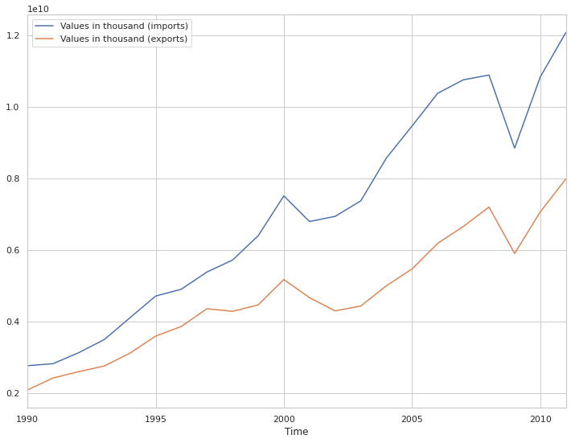

```python
for_corr.plot()
```

This tells us that there has always been more imports then exports. Also starting in the 2000s, the value difference of imports and exports starts to grow bigger meaning that the United States is starting to primarily import more technology goods than creating and exporting it to other countries.

Gov. spending on technology sectors

```python
import pandas as pd
# Read in the government spending dataset
rsdv = pd.read_csv("gov_spending.csv")
#export_imports.drop(labels=["COU","Partners","FLW","PAR","CAT","IND","VAL","TIME","Flag Codes","Flags","Value"], inplace=True, axis=1)


rsdv.drop(labels=["COUNTRY","INDUSTRY","CRITERIA","MEASURE","YEAR.1","Unit","PowerCode Code"
,"Reference Period Code","Reference Period Code","Reference Period","Flag Codes","Flags"], inplace=True, axis=1)

#Rename YEAR to Year and Value to Value in Millions
rsdv = rsdv.rename(columns={"YEAR": "Year", "Value": "Value in Millions"})
#rsdv

#There are nans in this dataset
rsdv.isnull().values.any()
#Checking which rows or row has nan
rsdv[rsdv.isnull().any(axis=1)]
#Deleting row 41 because there is nan under Value in Millions
rsdv = rsdv.dropna()
rsdv
```

|  | Country | Industry | Classification criteria | Measure | Year | Unit Code | PowerCode | Value in Millions |
| --- | --- | --- | --- | --- | --- | --- | --- | --- |
| 0 | United States | Manufacture of computer, electronic and optica... | Main activity | National Currency | 2008 | USD | Millions | 60464.0 |
| 1 | United States | Manufacture of computer, electronic and optica... | Main activity | National Currency | 2009 | USD | Millions | 56435.0 |
| 2 | United States | Manufacture of computer, electronic and optica... | Main activity | National Currency | 2010 | USD | Millions | 59875.0 |
| 3 | United States | Manufacture of computer, electronic and optica... | Main activity | National Currency | 2011 | USD | Millions | 62704.0 |
| 4 | United States | Manufacture of computer, electronic and optica... | Main activity | National Currency | 2012 | USD | Millions | 65068.0 |
| ... | ... | ... | ... | ... | ... | ... | ... | ... |
| 94 | United States | Scientific research and development | Main activity | National Currency | 2014 | USD | Millions | 12807.0 |
| 95 | United States | Scientific research and development | Main activity | National Currency | 2015 | USD | Millions | 16329.0 |
| 96 | United States | Scientific research and development | Main activity | National Currency | 2016 | USD | Millions | 14842.0 |
| 97 | United States | Scientific research and development | Main activity | National Currency | 2017 | USD | Millions | 17321.0 |
| 98 | United States | Scientific research and development | Main activity | National Currency | 2018 | USD | Millions | 20185.0 |

98 rows × 8 columns

Start to tidy up dataset

```python
rsdv["Industry"].value_counts()
```

```
Manufacture of computer, electronic and optical products    11
Manufacture of computers and peripheral equipment           11
INFORMATION AND COMMUNICATION (J)                           11
Software publishing                                         11
Computer programming, consultancy and related activities    11
Information service activities                              11
PROFESSIONAL, SCIENTIFIC, AND TECHNICAL ACTIVITIES (M)      11
Scientific research and development                         11
Telecommunications                                          10
Name: Industry, dtype: int64
```

```python
#Here we make a dataFrame with selective Industries: Software publishing and scientific research and development
randd = pd.DataFrame(rsdv[rsdv["Industry"] == "Scientific research and development"])
software = pd.DataFrame(rsdv[rsdv["Industry"] == "Software publishing"])
software

#New Dataframe
industries = pd.concat([randd, software])
industries = industries[["Year",'Value in Millions']].sort_values(by="Year",ascending=True)
industries.reset_index()
industries.set_index("Year")
```

| Year | Value in Millions |
| --- | --- |
| 2008 | 17913.0 |
| 2008 | 28221.0 |
| 2009 | 17270.0 |
| 2009 | 26394.0 |
| 2010 | 14818.0 |
| 2010 | 26191.0 |
| 2011 | 15301.0 |
| 2011 | 27965.0 |
| 2012 | 16544.0 |
| 2012 | 28745.0 |
| 2013 | 14201.0 |
| 2013 | 35333.0 |
| 2014 | 12807.0 |
| 2014 | 36052.0 |
| 2015 | 16329.0 |
| 2015 | 33248.0 |
| 2016 | 33495.0 |
| 2016 | 14842.0 |
| 2017 | 34264.0 |
| 2017 | 17321.0 |
| 2018 | 20185.0 |
| 2018 | 32639.0 |

We want to see the relationship of exports, imports, and research and development throughout the year.

```python
#converting years into datetime format
industries['Year'] = pd.to_datetime(industries["Year"],format="%Y")
```

[figure not shown]

```python
#plotting the industry(black) along with imports and exports
import matplotlib.pyplot as plt

#.plot(figsize=(12,4))
#for_corr.plot()
#perceptions_AI.groupby("Year")["AI Mood"].sum().plot(figsize=(12,4),color="blue")
fig,axis = plt.subplots()
perceptions = pd.DataFrame(perceptions_AI.groupby("Year")["AI Mood"].sum())
perceptions
axis2 = axis.twinx()
axis.plot(for_corr.index,for_corr[["Values in thousand (imports)", "Values in thousand (exports)"]])
axis.set_xlabel('Year', fontsize=14)
axis.set_ylabel("(imports and exports)",fontsize=14)
axis2.set_ylabel("R&D",fontsize=14)
axis2.plot(perceptions.index, perceptions["AI Mood"],color="black")
axis.legend(["imports","exports",])
axis2.legend(["R&D"])
```

We want to use this analysis to see how less technological innovation in the United States affects peoples mood towards AI and their behaviors towards the stock market.

```python
for_corr.reset_index(inplace=True)
industries.reset_index(inplace=True)
```

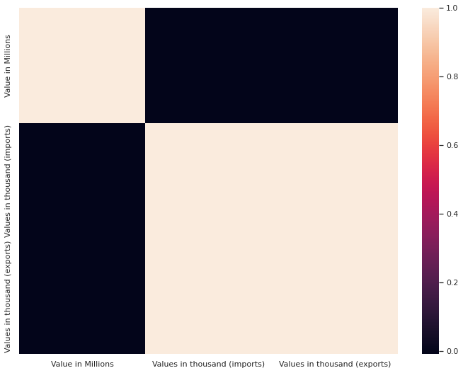

```python
#Broadcasting to get the same value
import seaborn as sns

industries["Value in Millions"] = industries["Value in Millions"] * 10**6
for_corr["Values in thousand (imports)"] = for_corr["Values in thousand (imports)"] * 10**3
for_corr["Values in thousand (exports)"] = for_corr["Values in thousand (imports)"] * 10**3

#for_corr.reset_index(inplace=True)
for_corr.rename(columns={"Time":"Year"}, inplace=True)
#for_corr.drop(labels=["level_0","index"],axis=1,inplace=True)
#industries.reset_index(inplace=True)
#industries.drop(labels=["level_0","index"],axis=1,inplace=True)
merged = industries.merge(for_corr,on=["Year"], how="outer")
merged.drop(labels=["index"], inplace=True, axis=1)
#display(merged)
#correlation = for_corr["Values in thousand (imports)"].corr(industries["Value in Millions"])
#print(correlation)
new_corr = merged.corr()
sns.heatmap(new_corr)
```

We want to use this information to see if importing new technologies causes people to have a more positive outlook of AI.

```python
correlation = for_corr["Values in thousand (imports)"].corr(industries["Value in Millions"])
correlation
```

```
0.2563722242687048
```

```python
#Created a pivot table to have a more clear grapgh
rsdv1 = pd.pivot_table(rsdv,values=["Value in Millions"], index=["Year"], columns=["Industry"])
rsdv1 = rsdv1.dropna()
rsdv1
```

| Industry Year | Value in Millions Computer programming, consultancy and related activities | Value in Millions INFORMATION AND COMMUNICATION (J) | Value in Millions Information service activities | Value in Millions Manufacture of computer, electronic and optical products | Value in Millions Manufacture of computers and peripheral equipment | Value in Millions PROFESSIONAL, SCIENTIFIC, AND TECHNICAL ACTIVITIES (M) | Value in Millions Scientific research and development | Value in Millions Software publishing | Value in Millions Telecommunications |
| --- | --- | --- | --- | --- | --- | --- | --- | --- | --- |
| 2008 | 12146.0 | 49841.0 | 6567.0 | 60464.0 | 9776.0 | 25808.0 | 17913.0 | 28221.0 | 1684.0 |
| 2009 | 12560.0 | 46366.0 | 2735.0 | 56435.0 | 8095.0 | 32387.0 | 17270.0 | 26394.0 | 1496.0 |
| 2010 | 11050.0 | 47902.0 | 2538.0 | 59875.0 | 9032.0 | 22640.0 | 14818.0 | 26191.0 | 1868.0 |
| 2011 | 13259.0 | 55124.0 | 4285.0 | 62704.0 | 9855.0 | 24960.0 | 15301.0 | 27965.0 | 2157.0 |
| 2012 | 11251.0 | 58056.0 | 4913.0 | 65068.0 | 7799.0 | 23058.0 | 16544.0 | 28745.0 | 2824.0 |
| 2013 | 9268.0 | 66475.0 | 6446.0 | 67205.0 | 6269.0 | 21749.0 | 14201.0 | 35333.0 | 3041.0 |
| 2014 | 11019.0 | 74792.0 | 9029.0 | 73891.0 | 7444.0 | 19956.0 | 12807.0 | 36052.0 | 3755.0 |
| 2015 | 14333.0 | 79846.0 | 9416.0 | 72110.0 | 8106.0 | 24293.0 | 16329.0 | 33248.0 | 3607.0 |
| 2017 | 13327.0 | 93578.0 | 16155.0 | 78575.0 | 21231.0 | 23596.0 | 17321.0 | 34264.0 | 3744.0 |
| 2018 | 15923.0 | 110272.0 | 23306.0 | 83697.0 | 22811.0 | 28937.0 | 20185.0 | 32639.0 | 3696.0 |

[figure not shown]

```python
from matplotlib import ticker
ax = rsdv1.plot(kind='barh', stacked=True,title='2019 Passenger Totals\n(source: BTS)'
)
ax.invert_yaxis() # put destinations with more passengers on top
# formatting
ax.set(xlabel='Values in Millions', ylabel='Year')
ax.legend(title='Industry')
# removes the top and right lines from the figure to make it less boxy
for spine in ['top', 'right']:
    ax.spines[spine].set_visible(False)
```

This shows the amount of money that the government puts towards each Research and Development industry. The most goes towards Manufacture of computer, electronic and optical products and INFORMATION AND COMMUNICATION (J). The least is Telecommunications.

Predictions:

the next model that we would want to make would incorporate the stocks that we still have not used enough off. we would want to make a prediction between how rises and dips in research, exports and imports relate to the AI perception Data set and finally how this has an effect on the stocks of a bunch of technology companies.